# Health and Economic Consequences of Severe Weather Events

Omar Safwat

12/9/2020

# SYNOPSIS

This document presents an analysis of the NOAA Storm Database, addressing the economical and health consequences of severe weather events. The data records events taking place between 1950 and 2011 across the USA. The analysis was conducted by reading set of data recording information relevant to Property damage, Crop damage in USD, in addition to number of Fatalities and Injuries. The analysis shows that Tornado and Flooding events have the highest health and economical impact, respectively.

# 1. DATA PROCESSING

Attaching the required packages

```r
library(data.table)
library(stringdist)
library(dplyr)
library(ggplot2)
```

## 1.1. Reading the data

The [NOAA Storm Data](https://d396qusza40orc.cloudfront.net/repdata%2Fdata%2FStormData.csv.bz2) was acquired in .bz2 format. In addition, The [Storm Data Documentation](https://d396qusza40orc.cloudfront.net/repdata%2Fpeer2_doc%2Fpd01016005curr.pdf) and [FAQ](https://d396qusza40orc.cloudfront.net/repdata%2Fpeer2_doc%2FNCDC%20Storm%20Events-FAQ%20Page.pdf) were consulted to interpret the data structure, and, therefore, drive the data processing.

To start off, the Storm data in .bz2 format was directly read by the function `fread()` from the data.table package. Since the raw data consists of almost a million observations and 37 variables, only columns relevant to economical damage and public health were kept.

```r
data <- fread("repdata_data_StormData.csv.bz2", select = c(7:8, 23:28), data.table = FALSE)
head(data)
```

```
##   STATE  EVTYPE FATALITIES INJURIES PROPDMG PROPDMGEXP CROPDMG CROPDMGEXP
## 1    AL TORNADO          0       15    25.0          K       0
## 2    AL TORNADO          0        0     2.5          K       0
## 3    AL TORNADO          0        2    25.0          K       0
## 4    AL TORNADO          0        2     2.5          K       0
## 5    AL TORNADO          0        2     2.5          K       0
## 6    AL TORNADO          0        6     2.5          K       0
```

## 1.2. Processing Event Types

After careful inspection of the values under the variable EVTYPE, I’ve noticed that many values were written as a combination of several of the distinct 48 Event types defined in the Storm Data Documentation, section 2.1.1. Furthermore, the values under EVTYPE column are not written consistently, and several typos have been spotted resulting in almost a 1000 unique values, as opposed to the confirmed 48 values in the Data document, as seen below.

```r
length(unique(data$EVTYPE))
```

```
## [1] 985
```

Subsequently, this particular column necessitates additional processing steps. First, I’ll attempt to unite these synonymous values, by converting all of them to lower cases, and remove all unnecessary spaces or extra back and forward slashes, as well as punctuation and numeric. As seen below, after this subtle manipulation the numbers are already down to 758.

```r
#Converting all names in EVTYPE to lower, for easier matching
data$EVTYPE <- tolower(data$EVTYPE)
#Remove all numbers and points from EVTYPE
data$EVTYPE <- gsub("[0-9]|\\.", "", data$EVTYPE)
#Removing unnecessary multiple spaces in the middle of words
data$EVTYPE <- gsub(" +", " ", data$EVTYPE)
#Removing single spaces at the end and beginning of events
data$EVTYPE <- gsub("(^\\s)|(\\s$)", "", data$EVTYPE)
#Convert all backslashes to forward and remove extra spaces before or after them
data$EVTYPE <- gsub("\\\\", "/", data$EVTYPE)
data$EVTYPE <- gsub("() */+ *)|([ ]*-[ ]*)", "/",data$EVTYPE)
length(unique(data$EVTYPE))
```

```
## [1] 758
```

One way to approach this problem of inconsistent values would be to match them to the original 48 values, however, this would result to a unrealistic and strenuous process of guessing values and and names of more than 700 values!. I believe this would result in inaccurate mutation of the data. A more convenient method is to pay attention to specific values, after extracting the most frequent unique words, which, given the size of the data, are more likely to skew the analysis.

```r
words <- paste(data$EVTYPE, collapse = " ")
uniqueWords <- strsplit(words, " ")[[1]]
wordCount <- as.data.frame(table(uniqueWords)) %>% arrange(desc(Freq))

head(wordCount,n = 50)
```

```
##     uniqueWords   Freq
## 1          wind 339082
## 2          hail 289333
## 3          tstm 227234
## 4  thunderstorm 109518
## 5         flood  81438
## 6       tornado  60685
## 7         flash  55043
## 8         heavy  27968
## 9         winds  22880
## 10         high  22826
## 11       winter  19600
## 12         snow  17446
## 13    lightning  15773
## 14        storm  15026
```

[output cut: 36 more lines]

```r
#create a temporary data table to store new corrected values without altering the original
temp <- data %>% as.data.table()

#Using regex to repair typos
temp[grepl("TSTM|THUNDERSTORM|LIGHTNING(?<!hail|rain|flood|flooding)$", EVTYPE, perl = TRUE, ignore.case = TRUE), EVTYPE := "thunderstorm"]
temp[grepl("WIND|MICROBURST|(?=.*MICRO)(?=.*BURST)", EVTYPE, perl=TRUE, ignore.case=TRUE), EVTYPE:="wind"]
temp[grepl("HAIL", EVTYPE, ignore.case=TRUE), EVTYPE:="hail"]
temp[grepl("FLOOD|FLD", EVTYPE, perl=TRUE, ignore.case=TRUE), EVTYPE:="flood"]
temp[grepl("TORNADO|FUNNEL|WATERSPOUT", EVTYPE, perl=TRUE, ignore.case=TRUE), EVTYPE:="tornado"]
temp[grepl("SLEET|SNOW", EVTYPE, perl=TRUE, ignore.case=TRUE), EVTYPE:="sleet and snow"]
temp[grepl("RAIN", EVTYPE, ignore.case=TRUE), EVTYPE:="rain"]
temp[grepl("SURF|TIDE|SURGE|RIP|CURRENT", EVTYPE, perl=TRUE, ignore.case=TRUE), EVTYPE:="surftide"]
temp[grepl("ICE|FREEZ|FROST|FROZEN|COLD|CHILL", EVTYPE, perl=TRUE, ignore.case=TRUE), EVTYPE:="cold"]
temp[grepl("BLIZZARD|(?=.*ICE)(?=.*STORM)|(?=.*SNOW)(?=.*STORM)|(?=.*WINTER)(?=.*STORM)|(?=.*LAKE)(?=.*EFFECT)", EVTYPE, perl=TRUE, ignore.case=TRUE), EVTYPE:="blizzard"]
temp[grepl("DUST", EVTYPE, ignore.case=TRUE), EVTYPE:="dust"]
temp[grepl("WILDFIRE|(?=.*WILD)(?=.*FIRE)|(?=.*FOREST)(?=.*FIRE)", EVTYPE, perl=TRUE, ignore.case=TRUE), EVTYPE:="fire"]
temp[grepl("HEAT|WARM", EVTYPE, perl=TRUE, ignore.case=TRUE), EVTYPE:="heat"]
temp[grepl("(?=.*DRY)(?=.*WARM)|DROUGHT", EVTYPE, perl=TRUE, ignore.case=TRUE), EVTYPE:="drought"]
temp[grepl("FOG", EVTYPE, ignore.case=TRUE), EVTYPE:="fog"]
temp[grepl("HURRICANE|TYPHOON|(?=.*TROPICAL)(?=.*STORM)(?=.*depression)", EVTYPE, perl=TRUE, ignore.case=TRUE), EVTYPE:="tropical storm"]
temp[grepl("LANDSLIDE", EVTYPE, ignore.case=TRUE), EVTYPE:="landslide"]
temp[grepl("AVALANCHE", EVTYPE, ignore.case=TRUE), EVTYPE:="avalanche"]

## Only observations with any of the new types of weather are kept.
cleanData <- temp %>% filter(grepl("^thunderstorm$|^wind$|^hail$|^flood$|^tornado$|^sleet and snow$|^rain$|^surftide$|^cold$|^blizzard$|^dust$|^fire$|^heat$|^drought$|^fog$|^tropical storm$|^landslide$|^avalanche$", EVTYPE, perl=TRUE)) %>% as.data.frame()

cleanData$EVTYPE <- as.factor(as.character(cleanData$EVTYPE))
```

Using the above categorization, as seen below, approximately 1% of the values under EVTYPE couldn’t be matched. Out of a neraly 1 million observations, this is acceptable.

```r
paste((nrow(data) - nrow(cleanData)) * 100 /nrow(data), "%")
```

```
## [1] "1.01518679547865 %"
```

## 1.3. Processing property and crop damage

The property and crop damage are stored in the original set under `PROPDMG`, `CROPDMG`, `PROPDMGEXP` and `CROPDMGEXP`, where the variables ending with `EXP`, are the value of exponents, example: `k` or `K` stand for kilos or thousand. Interpretation of these values can be found [here](https://rstudio-pubs-static.s3.amazonaws.com/58957_37b6723ee52b455990e149edde45e5b6.html). Total damage is assigned to a new column `TOTDMG` in the following code.

```r
#Converting symbols to their numeric interpretations
#Property damage column
cleanData$PROPDMG <- as.numeric(cleanData$PROPDMG)
cleanData <- cleanData %>% mutate(PROP.DAMAGE = ifelse(grepl("h|H", PROPDMGEXP), PROPDMG * 10^2,
                ifelse(grepl("k|K", PROPDMGEXP), PROPDMG * 10^3,
                ifelse(grepl("m|M", PROPDMGEXP), PROPDMG * 10^6,
                ifelse(grepl("b|B", PROPDMGEXP), PROPDMG * 10^9,
                ifelse(grepl("[0-8]", PROPDMGEXP), PROPDMG * 10,
                ifelse(grepl("+", PROPDMGEXP), PROPDMG * 1, 0)))))))

#Crop damage column
cleanData$CROPDMG <- as.numeric(cleanData$CROPDMG)
cleanData <- cleanData %>% mutate(CROP.DAMAGE =
                ifelse(grepl("h|H", CROPDMGEXP), CROPDMG * 10^2,
                ifelse(grepl("k|K", CROPDMGEXP), CROPDMG * 10^3,
                ifelse(grepl("m|M", CROPDMGEXP), CROPDMG * 10^6,
                ifelse(grepl("b|B", CROPDMGEXP), CROPDMG * 10^9,
                ifelse(grepl("[0-8]", CROPDMGEXP), CROPDMG * 10,
                ifelse(grepl("+", CROPDMGEXP), CROPDMG * 1, 0)))))))
#Creating column of Total damage
cleanData <- cleanData %>% mutate(TOTDMG = PROP.DAMAGE + CROP.DAMAGE)
```

# 2. RESULTS

The following analysis will attempt the following: 1. What types of weather events are most harmful to the population’s health across all states. 2. What types of weather events have greater economic consequences across all states.

## 2.1. Health consequences

For this analysis, the sum of the two variables `INJURIES` and `FATALITIES` will represent all health consequences conveyed to the population by each event type.

```r
#Group the data by the type of event and arrange them in descending order
cleanData <- transform(cleanData, factor(EVTYPE))
healthRisk <- group_by(cleanData, EVTYPE)
healthRisk <- healthRisk %>%
    summarize(fatalities = sum(FATALITIES),
              injuries = sum(INJURIES),
              total = sum(FATALITIES + INJURIES)) %>%
    arrange(desc(total))
head(healthRisk)
```

```
## # A tibble: 6 x 4
##   EVTYPE       fatalities injuries total
##   <fct>             <dbl>    <dbl> <dbl>
## 1 tornado            5639    91439 97078
## 2 thunderstorm       1571    14774 16345
## 3 heat               3178     9243 12421
## 4 flood              1553     8683 10236
## 5 cold                317     2450  2767
## 6 wind                701     2022  2723
```

One can conclude from the table above, that events and episodes exhibiting events like tornadoes, thunderstorms, heat and floods have the more severe outcomes to the public’s health. To represent this better, a bar plot is constructed in the next code. The data is also reshaped using the function `melt()` for easier plotting.

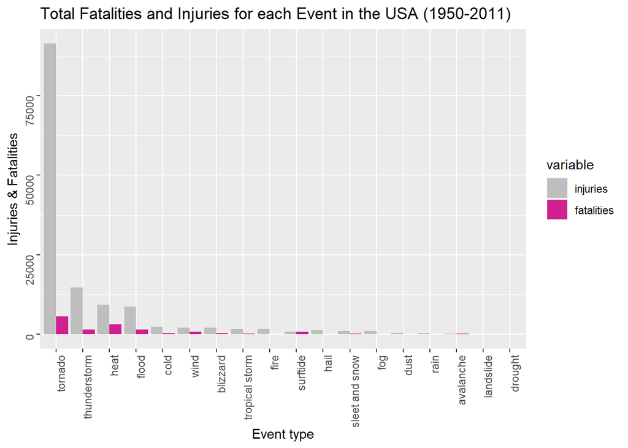

```r
#Create plot aesthetics
plot <- healthRisk %>% reshape2::melt(id.vars = c(1,4), measure.vars = c(3,2)) %>%
    ggplot(aes(x = reorder(EVTYPE, -total), y = value, fill = variable))

#Print plot with bars of same variable in "dodge" position
plot +
        geom_bar(position = "dodge", stat = "identity") +
        xlab("Event type") + ylab("Injuries & Fatalities") +
        ggtitle("Total Fatalities and Injuries for each Event in the USA (1950-2011)") +
        theme(axis.text = element_text(angle = 90, hjust = 1, vjust = 0.25)) +
        scale_fill_manual(values = c("grey", "violetred"))
```

## 2.2. Economical Damage

Similar to the previous approach, the economical damage can be interpreted, for each event, as the sum of property and crop damage, stored under the variable `TOTDMG`

```r
#Group the data by the type of event and arrange them in descending order
economicalDMG <- group_by(cleanData, EVTYPE)
economicalDMG <- economicalDMG %>%
    summarize(propDMG = sum(PROP.DAMAGE),
              cropDMG = sum(CROP.DAMAGE),
              total = sum(TOTDMG)) %>%
    arrange(desc(total))
head(economicalDMG)
```

```
## # A tibble: 6 x 4
##   EVTYPE              propDMG     cropDMG        total
##   <fct>                 <dbl>       <dbl>        <dbl>
## 1 flood          167581028869 12275747200 179856776069
## 2 tropical storm  92960300560  6184463800  99144764360
## 3 tornado         57002859450   414962960  57417822410
## 4 surftide        48076608500      855000  48077463500
## 5 hail            15974045934  3046837653  19020883587
## 6 drought          1046106000 13972566000  15018672000
```

A conclusion can be drawn from the data above that flood events seem to have the greatest financial loss, and that property damage for the majority of the first 5 events is more significant. A plot is created in the code below to further inspect this data.

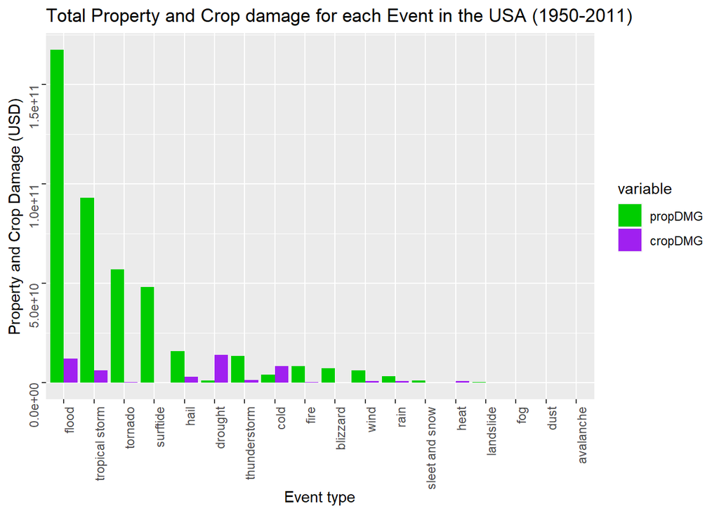

```r
#Create plot aesthetics
plot <- economicalDMG %>% reshape2::melt(id.vars = c(1,4), measure.vars = c(2,3)) %>%
    ggplot(aes(x = reorder(EVTYPE, -total), y = value, fill = variable))

#Print plot with bars of same variable in "dodge" position
plot +
        geom_bar(position = "dodge", stat = "identity") +
        xlab("Event type") + ylab("Property and Crop Damage (USD)") +
        ggtitle("Total Property and Crop damage for each Event in the USA (1950-2011)") +
        theme(axis.text = element_text(angle = 90, hjust = 1, vjust = 0.25)) +
        scale_fill_manual(values = c("green3", "purple"))
```